# Climatology Quality Control

```r
library(librarian)
shelf(tidyverse, ggplot2, ocedata, sf, units, R.matlab)
```

QC procedures following Gordana Lazin’s methodology for climatology data

# Filter data

Filter by existing quality control flags, selecting flags in c(0, 1, 2, 3, 6).

Filter by distance from coastline, excluding data points within 5km of the coast (using Dan Kelley’s ocedata, coastlineWorldFine object)

Filter data to reduce QC issues requiring attention.

```
Ammonia
1493 points removed based on data flag!
7824 points filtered by coastal position!
Chlorophyll A
314 points removed based on data flag!
10791 points filtered by coastal position!
Nitrate
452 points removed based on data flag!
11093 points filtered by coastal position!
Nitrite
434 points removed based on data flag!
9186 points filtered by coastal position!
O2
203 points removed based on data flag!
1509 points filtered by coastal position!
Phaeophytin
71 points removed based on data flag!
5980 points filtered by coastal position!
Phosphate
511 points removed based on data flag!
11064 points filtered by coastal position!
Salinity
855 points removed based on data flag!
10975 points filtered by coastal position!
Silicate
411 points removed based on data flag!
11009 points filtered by coastal position!
```

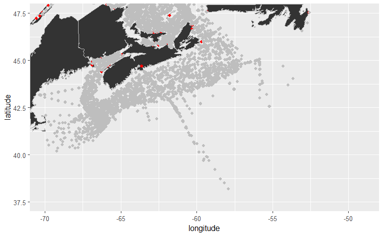

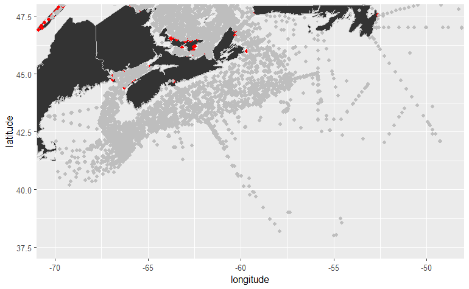

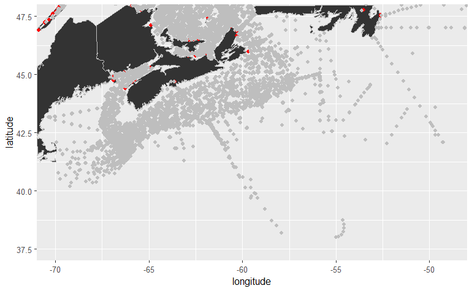

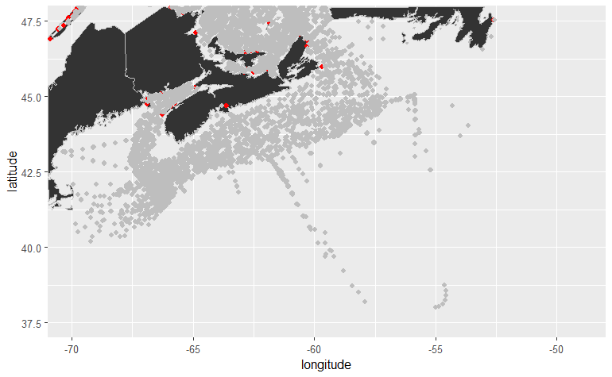

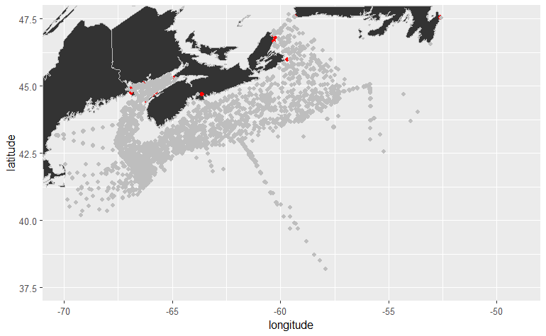

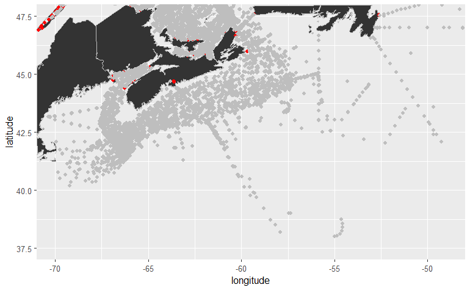

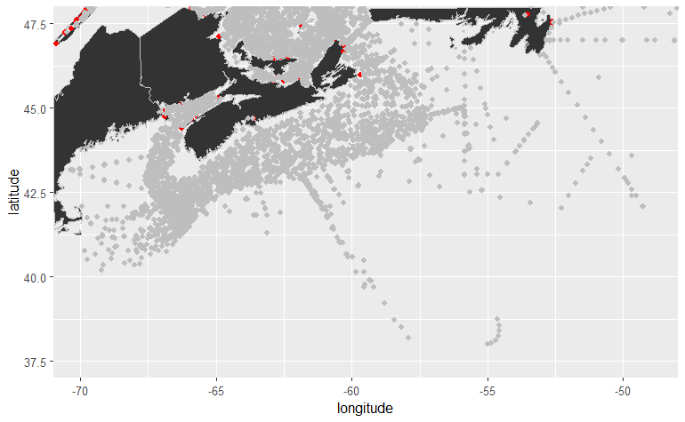

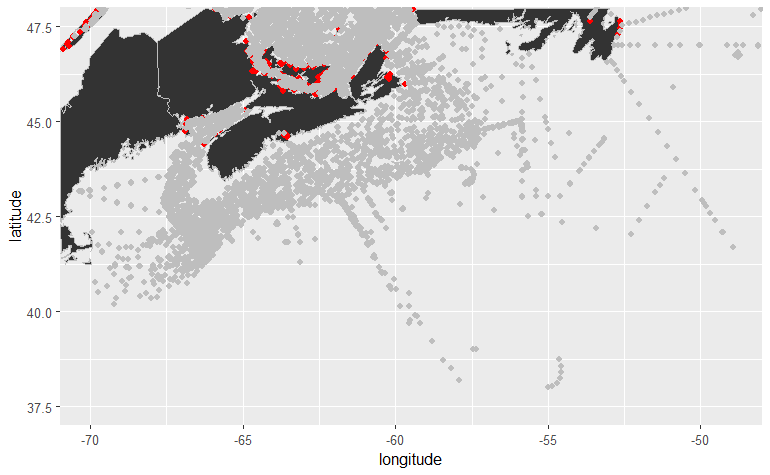

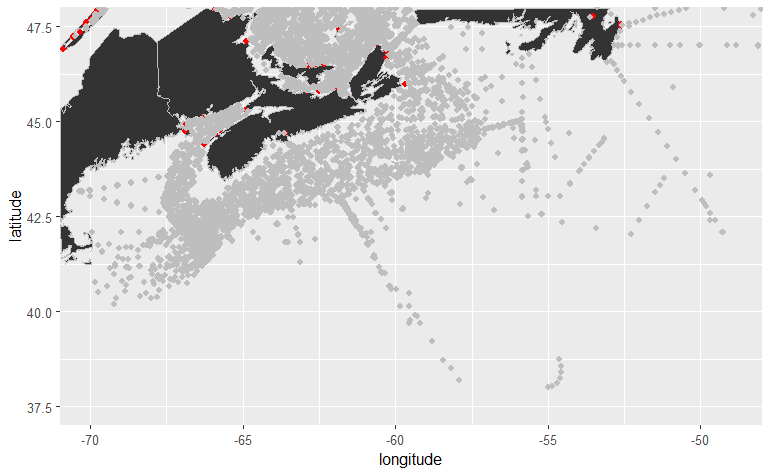

```r
for (l in 1:length(data_fns)) {

  data <- read.csv(data_fns[l])
  param_name <- unique(data$PARAMETER_NAME)
  cat(param_name, '\n')
  # filter based on QC codes

  data_f <- data %>%
    filter(DATA_QC_CODE %in% c(0, 1, 2, 3, 6))
 cat(nrow(data) - nrow(data_f))
 cat(' points removed based on data flag! \n')
  # filter on spatial
  # 5 km from coast

  data_l <- data_f %>%
  select(NAME, EVENT_MIN_LON, EVENT_MIN_LAT, COLLECTOR_EVENT_ID, COLLECTOR_SAMPLE_ID)

# Convert data frames to simple feature objects
points <- st_as_sf(data_l, coords = c("EVENT_MIN_LON", "EVENT_MIN_LAT"), crs = 4326)


#line.sf <- st_sf(id = 'L1', st_sfc(st_linestring(as.matrix(clwf), dim = "XY")))
#st_crs(line.sf) <- st_crs(4326) # assign crs

# EPSG:32620
points <- st_transform(points, 32620)
#coastline <- st_transform(line.sf, crs = 32620)

# Perform spatial join
intersects <- st_intersects(points, onebuff, sparse = FALSE)

# Filter points
selected_points <- points[!intersects, ]

# Calculate distance from each point to the coastline
#distances <- st_distance(points, coastline)

# Select points within 5km of the coastline
#selected_points <- points[distances <= units::set_units(5000, 'meters'), ]

# cat(length(which(data_f$COLLECTOR_SAMPLE_ID %in% selected_points$COLLECTOR_SAMPLE_ID)))
# cat(' points retained from coastline filtering!\n')
cat(length(intersects[intersects == TRUE]))
cat(' points filtered by coastal position! \n')

data_f2 <- data_f[which(data_f$COLLECTOR_SAMPLE_ID %in% selected_points$COLLECTOR_SAMPLE_ID),]

# plot

coast_data <- data_f[-which(data_f$COLLECTOR_SAMPLE_ID %in% selected_points$COLLECTOR_SAMPLE_ID),]

pp <- ggplot() +
  geom_polygon(data = fullcoast, aes(x = longitude, y = latitude), colour = 'grey')+
  geom_point(data = coast_data, aes(x = EVENT_MIN_LON, y = EVENT_MIN_LAT), colour = 'red')+
  geom_point(data = data_f2, aes(x = EVENT_MIN_LON, y = EVENT_MIN_LAT), colour = 'grey')+
  scale_x_continuous(limits = c(-71, -48), expand = c(0,0))+
    scale_y_continuous(limits = c(37, 48), expand = c(0,0))

print(pp)

# save filtered dataset

 # write.csv(data_f2, paste0('data/filtered_data/SS_', param_name, '_', Sys.Date(), '.csv'))
 }
```

Filter data to be contained within climatology boxes.

```
Ammonia
13053 points removed outside of climatology boxes!
Chlorophyll A
22989 points removed outside of climatology boxes!
Nitrate
24572 points removed outside of climatology boxes!
Nitrite
21569 points removed outside of climatology boxes!
O2
919 points removed outside of climatology boxes!
Phaeophytin
11137 points removed outside of climatology boxes!
Phosphate
24553 points removed outside of climatology boxes!
Salinity
20974 points removed outside of climatology boxes!
Silicate
24104 points removed outside of climatology boxes!
```

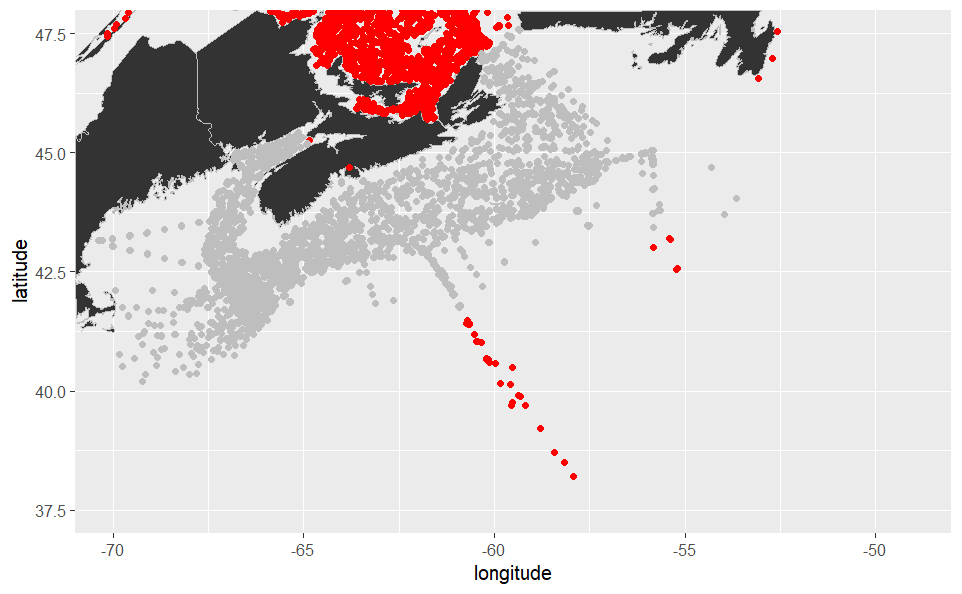

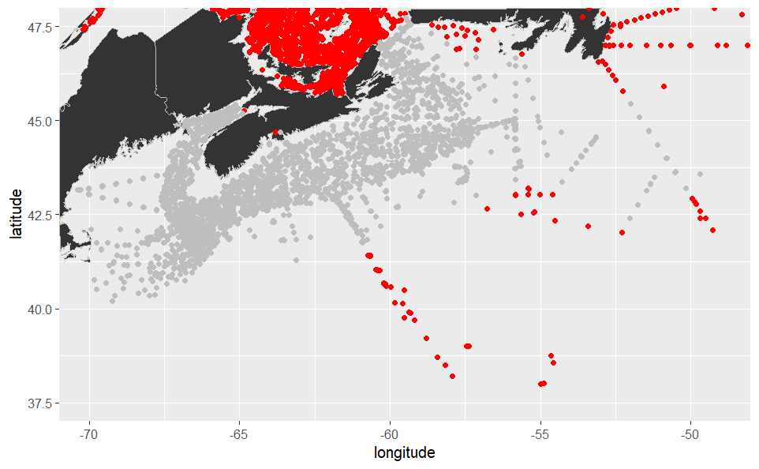

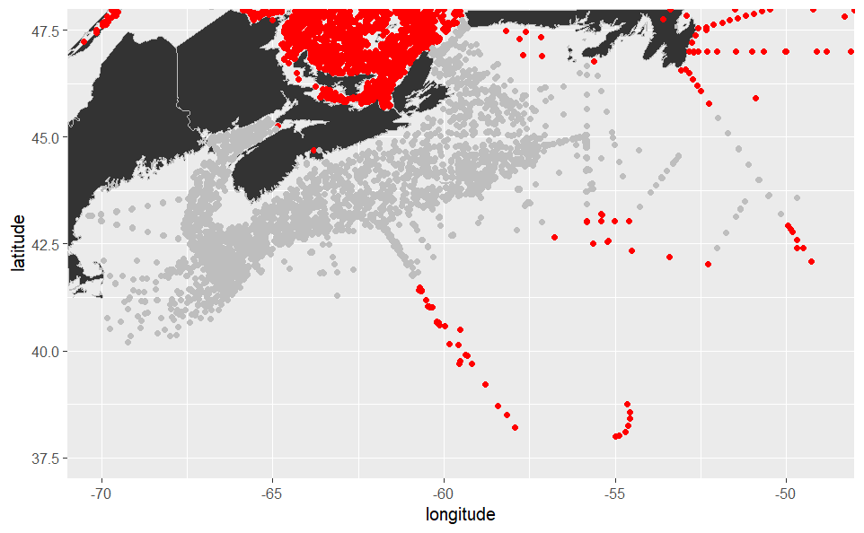

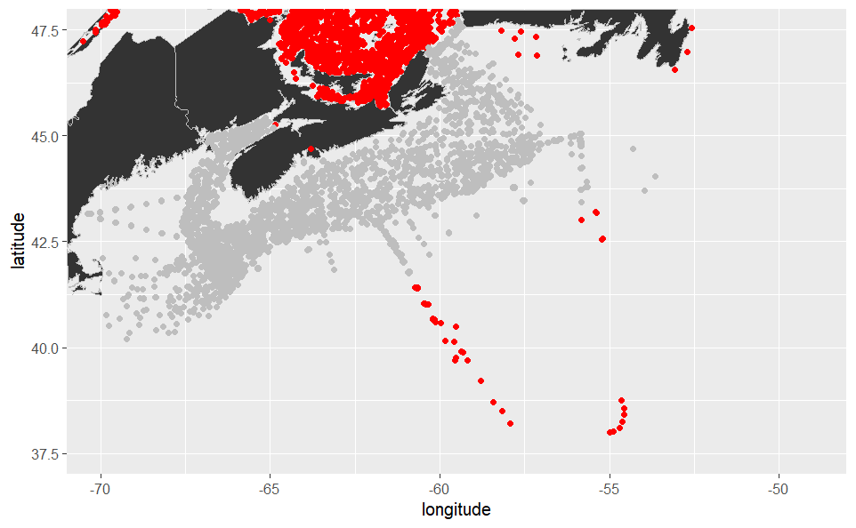

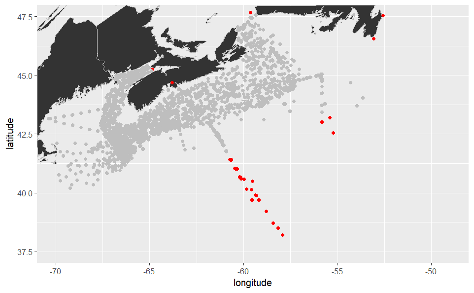

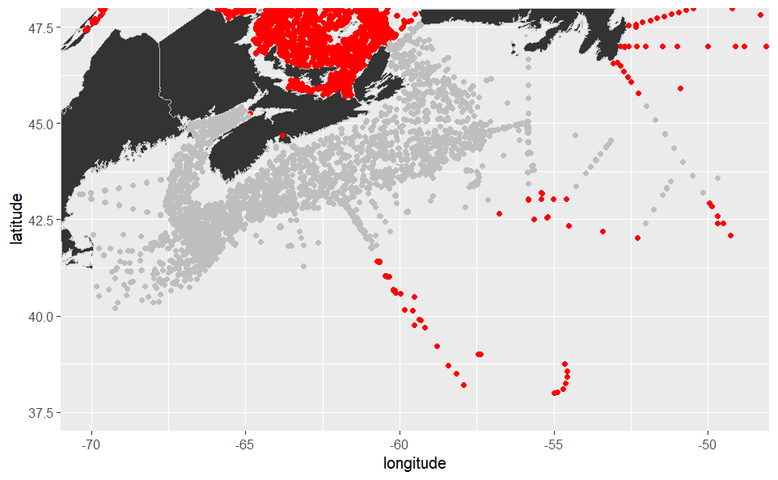

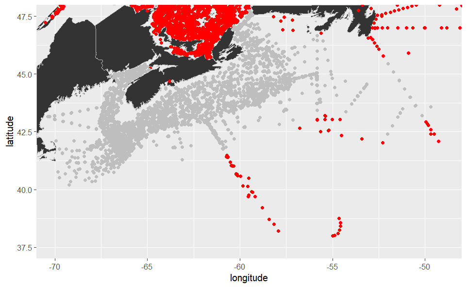

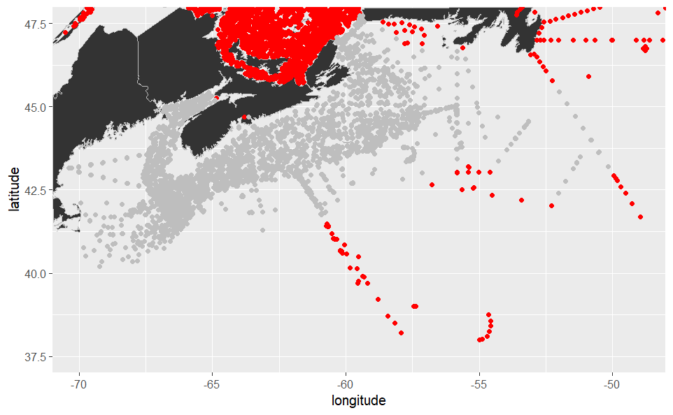

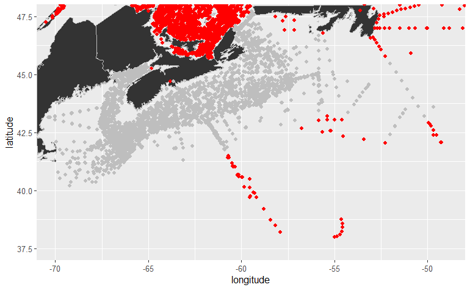

```r
# load in climatology boxes
boxdat <- read.csv("Gordana/2014_boxes.csv")

# Convert your dataframe to a spatial object
df_sf <- st_as_sf(boxdat, coords = c("longitude", "latitude"), crs = 4326)

# Create polygons
# Assuming each box consists of 4 points in order
df_poly <- df_sf %>%
  group_by(box) %>%
  summarise(geometry = st_combine(geometry), do_union = FALSE) %>%
  st_cast("POLYGON")

data_fns <- list.files('data/filtered_data/', pattern = '.csv', full.names = TRUE)

for (l in 1:length(data_fns)) {

  data <- read.csv(data_fns[l])
  param_name <- unique(data$PARAMETER_NAME)
  cat(param_name, '\n')
# use event location info because it is never 0
data_l <- data %>%
  select(NAME, EVENT_MIN_LAT, EVENT_MIN_LON, COLLECTOR_EVENT_ID, COLLECTOR_SAMPLE_ID)

df_l_sf <- st_as_sf(data_l, coords = c("EVENT_MIN_LON", "EVENT_MIN_LAT"), crs = 4326)

# Check if points  are within the boxes
within_boxes <- st_within(df_l_sf, df_poly)

outboxdata <- data[unlist(lapply(within_boxes, length)) == 0, ]
# Remove points not within any box from df_large
data_boxed <- data[unlist(lapply(within_boxes, length)) > 0, ]

cat(nrow(data) - nrow(data_boxed), 'points removed outside of climatology boxes! \n')

pp <- ggplot() +
  geom_polygon(data = fullcoast, aes(x = longitude, y = latitude), colour = 'grey')+
  geom_point(data = outboxdata, aes(x = EVENT_MIN_LON, y = EVENT_MIN_LAT), colour = 'red')+
  geom_point(data = data_boxed, aes(x = EVENT_MIN_LON, y = EVENT_MIN_LAT), colour = 'grey')+
  scale_x_continuous(limits = c(-71, -48), expand = c(0,0))+
    scale_y_continuous(limits = c(37, 48), expand = c(0,0))

print(pp)

write.csv(data_boxed, paste0('data/filtered_data/SS_boxed_', param_name, '_', Sys.Date(), '.csv'))
}
```

1. Check methodology All methods are comparable.
2. Check units All units match in initial_summary.Rmd
3. Check for empty fields in lat, lon, depth, data value